# Homework1

Burakhan Sel

18 Ekim 2018

## Task I

### Data Preparation

In order to do the task 1, we need to prepare our data. The preparation steps are shown below with the corresponding codes. Reading the data:

```r
odd_details <- readRDS("C:/Users/Burakhan/Desktop/Dersler/IE 582/df9b1196-e3cf-4cc7-9159-f236fe738215_odd_details.rds")
matches <- readRDS("C:/Users/Burakhan/Desktop/Dersler/IE 582/df9b1196-e3cf-4cc7-9159-f236fe738215_matches.rds")
```

Combining the data by the match of matchID:

```r
library(dplyr)
all_data<-left_join(x=odd_details,y=matches,by="matchId")
```

Creating a Data table to work efficiently with big data:

```r
typeof(all_data)
library(data.table)
all_data_DT<-data.table(all_data)
```

Since we only need to consider the bets that have “ou” as the betType, “2.5” as the totalhandicap and “over” as the oddtype, filtering is needed. Filtering the data by betType, totalhandicap and oddtype:

```r
odd_details_over<-all_data_DT[betType=="ou" & totalhandicap==2.5 & oddtype=="over"]
```

Converting the odds to probabilities:

```r
odd_details_over[,Probability:=1/odd ]
```

As a next step, I seperated the score column by “:” character as “text to column” in Excel. Then, I added a new column indicating whether the match score is over the totalhandicap or not. The new column has binary entries. 1 indicates that total score is grater than the totalhandicap and 0 indicates the less case.

```r
odd_details_over$score1 = as.numeric(lapply(strsplit(as.character(odd_details_over$score), split=":"), "[", 1))
odd_details_over$score2 = as.numeric(lapply(strsplit(as.character(odd_details_over$score), split=":"), "[", 2))
odd_details_over[,is_it_over:=as.numeric((score1+score2)>=totalhandicap)]
```

I utilized the “anytime” to convert as suggested in the homework description. Sorting the data by date of bets:

```r
library("anytime")
odd_details_over$date.x<-anytime(odd_details_over$date.x)#convert epoch to date
odd_details_over$date.y<-anytime(odd_details_over$date.y)#convert epoch to date
odd_details_over<-odd_details_over[order(as.POSIXct(odd_details_over$date.x))]
```

### a)

In the part a of the task 1, I plotted the fraction of games that are finished over in a bin versus average probability in the corresponding bin by following the steps that are explained below. I will explain the steps only for the first bookmakers final bets. For the rest of the anaylsis, I will comment on the graphs.

First analysis is for “bet at home”s final odds.

As a way of selecting bin intervals, I divided the range of max and min probabilities to number of bin that I determined. If I observe big estimated probabilities that are close to 1, I decrease the number of bin to increase the number of probabilities that are in the bins. By this way, I observe smaller and more realistic estimated probabilities.

#### Bookmaker = bet at home

##### By final bet

```r
number_of_bin<-7
```

Filtering the data by the bookmaker:

```r
bet_at_home_over<-odd_details_over[bookmaker=="bet-at-home"]
```

Adding a new column that indicates the bin ID:

```r
bet_at_home_over[,binId:=cut(bet_at_home_over$Probability,number_of_bin, labels = c(1:number_of_bin))]
```

Eliminating the multiple bets for a matchID and considering only the last bet:

```r
bet_at_home_over<-unique(bet_at_home_over,incomparables = FALSE, fromLast = TRUE, by="matchId")
```

Finding average probabilities and fraction of games for each bin:

```r
est_prob1<-0
avg_prob1<-0
for(i in 1:number_of_bin){
  est_prob1[i]<-nrow(bet_at_home_over[binId==i & is_it_over=="1"])/nrow(bet_at_home_over[binId==i])#Fraction of games
  avg_prob1[i]<-sum(bet_at_home_over[binId==i]$Probability)/nrow(bet_at_home_over[binId==i])}#Average Probability
```

Ploting the average versus fraction of games in addition to x=y line:

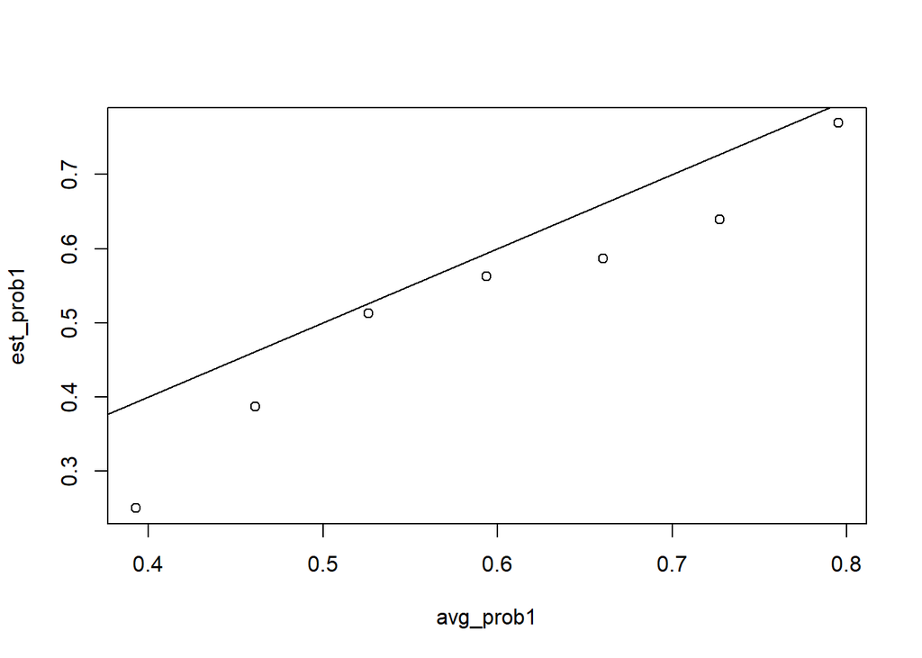

```r
plot(x=avg_prob1,y=est_prob1)
abline(a=0, b=1, untf = FALSE)
```

##### By initial bet

```r
number_of_bin<-7
```

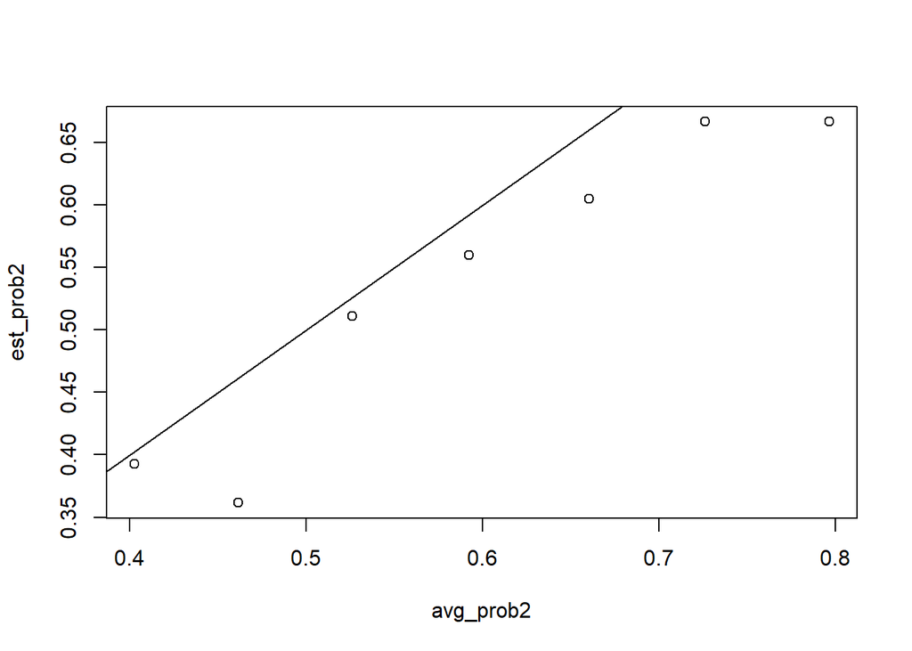

By comparing graphs of initial bets and final bets we can conclude that bet at home increased success of its guesses when match dates are closer. While the points that indicates estimated probability versus average probality in intial bets are generally under dy x=y line, the points come closer to the line in the final bets .

#### Bookmaker= Betsson

##### By final bet

```r
number_of_bin<-7
```

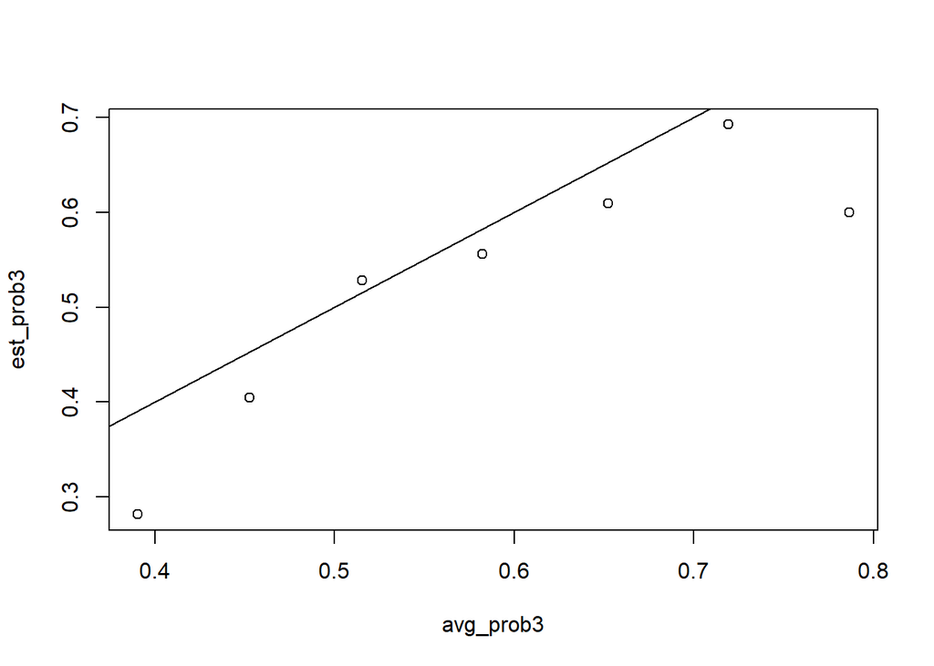

##### By initial bet

```r
number_of_bin<-7
```

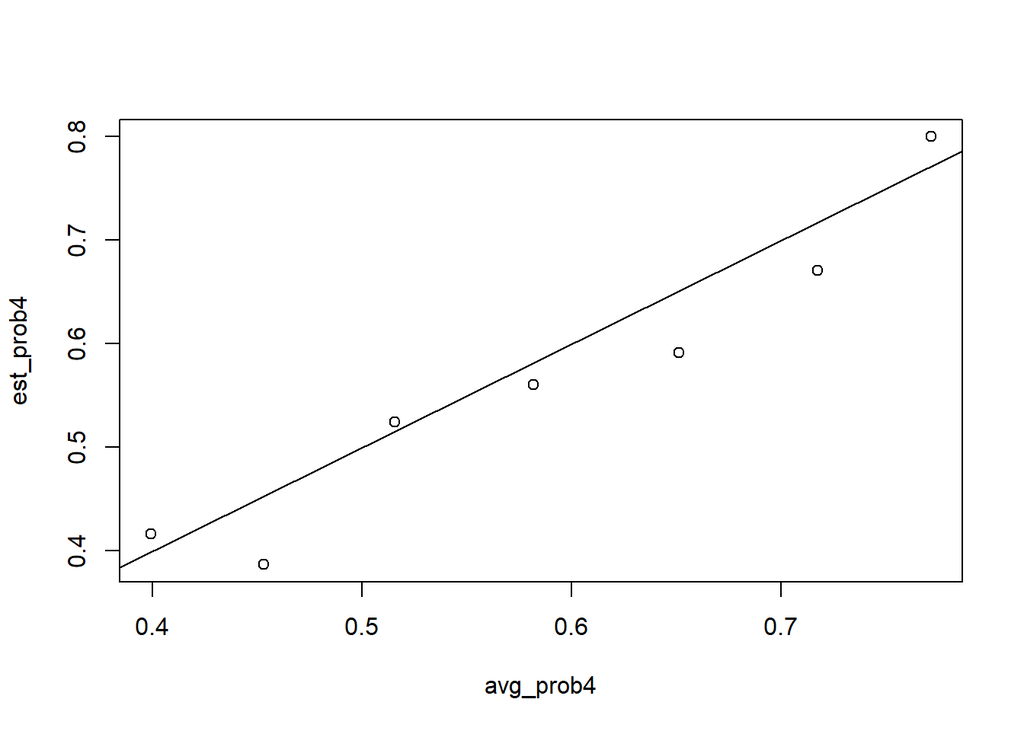

It seems like the success of the guesses of Betsson has decreasd with time. In initial bets graph, points are around x=y line but in the final bets graph,some points are far from the line. We can conclude that Betsson is successful at their initial guesses.

#### Bookmaker= 10Bet

##### By final bet

```r
number_of_bin<-10
```

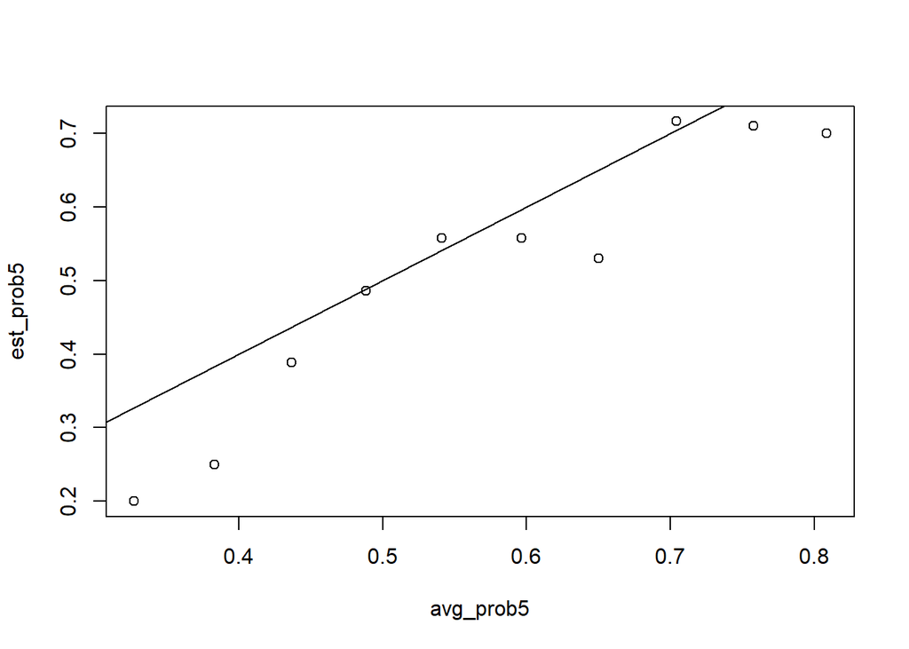

##### By initial bet

```r
number_of_bin<-10
```

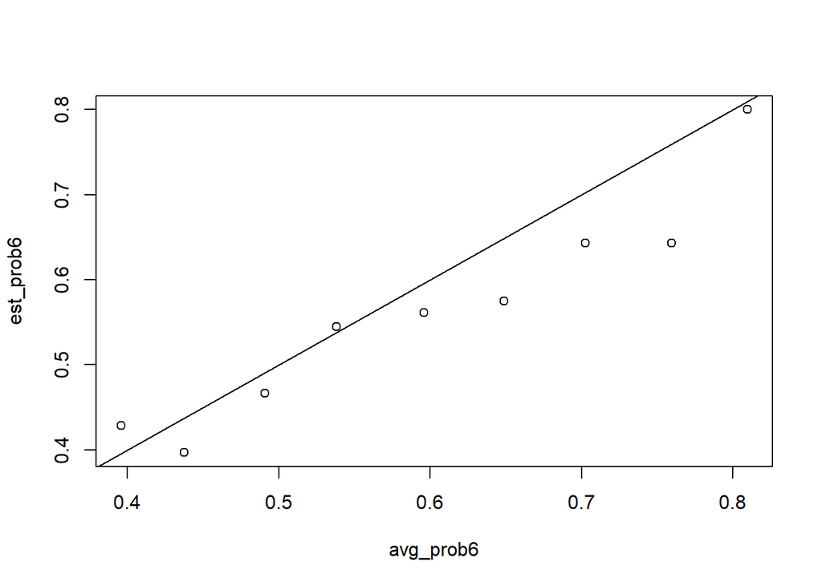

Although there is no significant improvement between initial bets and final bets, we can say that 10 bet is a succesfull bookmaker since the points are close to the line.

#### Bookmaker= Bet365

###### By final bet

```r
number_of_bin<-10
```

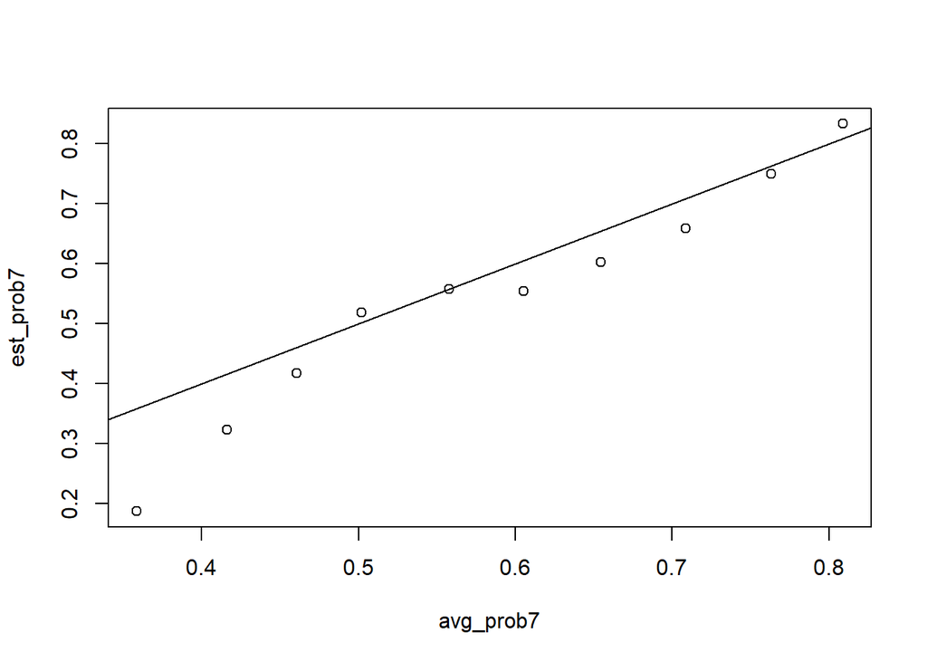

##### By initial bet

```r
number_of_bin<-10
```

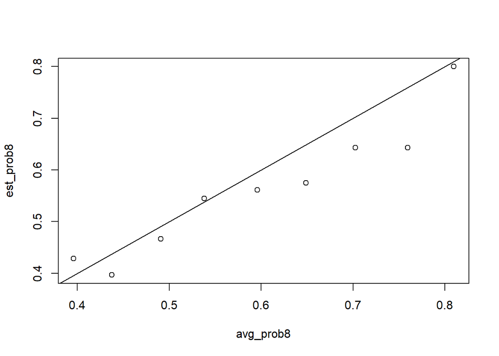

There is a significant improvement between the initial bets and the final bets of Bet365. In the final bets, Bet365 is so successful that the points are very close to the line.

#### Bookmaker= 12bet

##### By final bet

```r
number_of_bin<-10
```

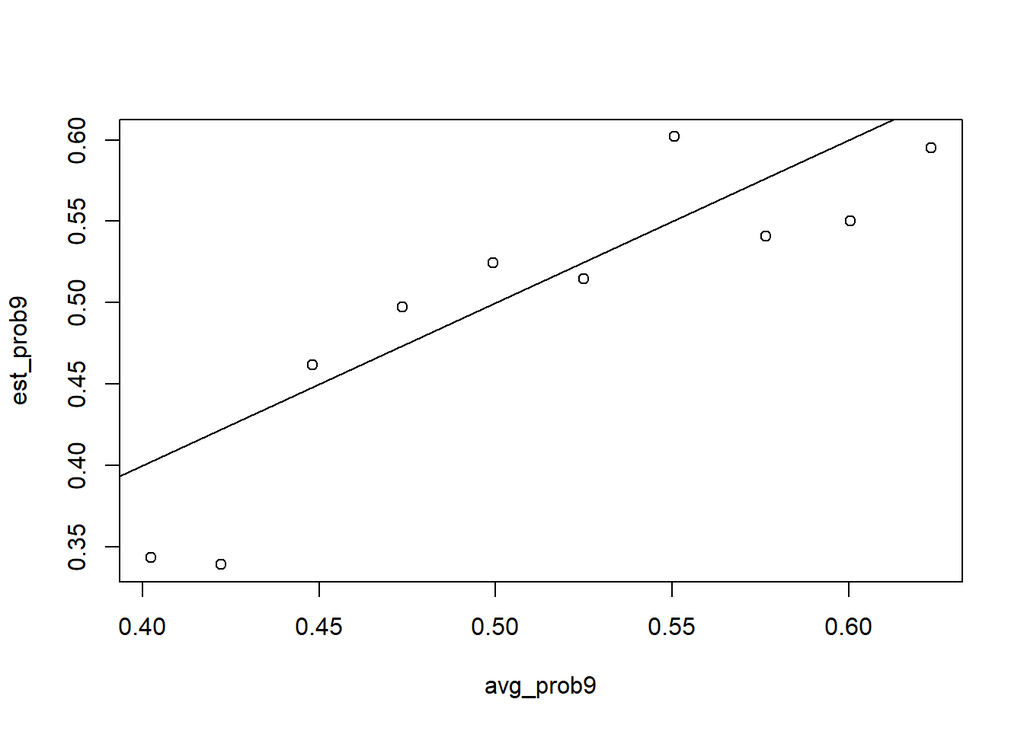

##### By initial bet

```r
number_of_bin<-10
```

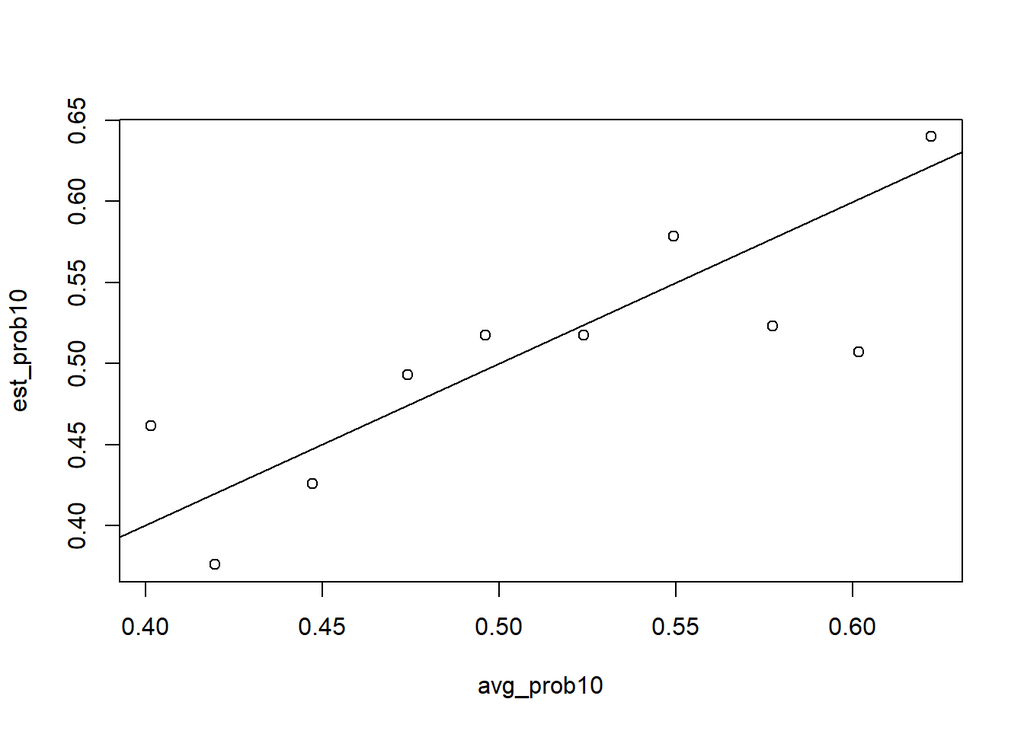

It seems like 12bet improved their guesses from initial to final but they are not successful enough in both of the cases since the deviations from the line are high.

#### Bookmaker= Tipico

##### By final bet

```r
number_of_bin<-10
```

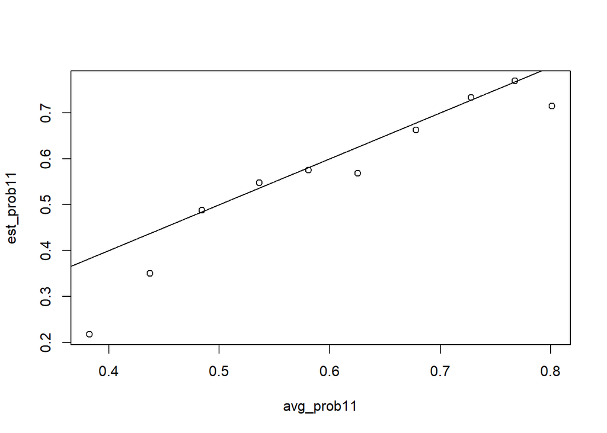

##### By initial bet

```r
number_of_bin<-10
```

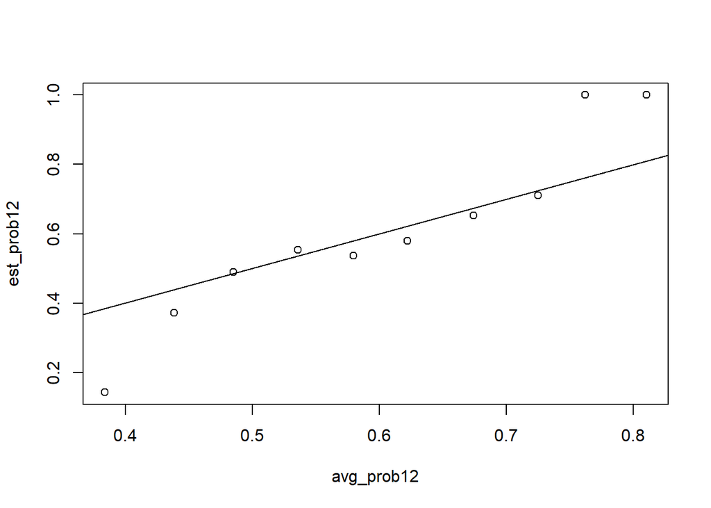

We should ignore the 1.0 estimated probability in the initial bet graph because it is an extreme point that is hard to avoid even with smaller number of bins. Apart from that, Tipico is very succesfull because the points are very close to the lines.

### b)

Fort he part b, I choose to analyse Bet365 which is a succesfull one and the one that improved itself from initial bets to final bets. In order to be clear, each bin is shown in seperate graphs. The number of bins is determined to be 5 so I decided to show 5 different graphs.

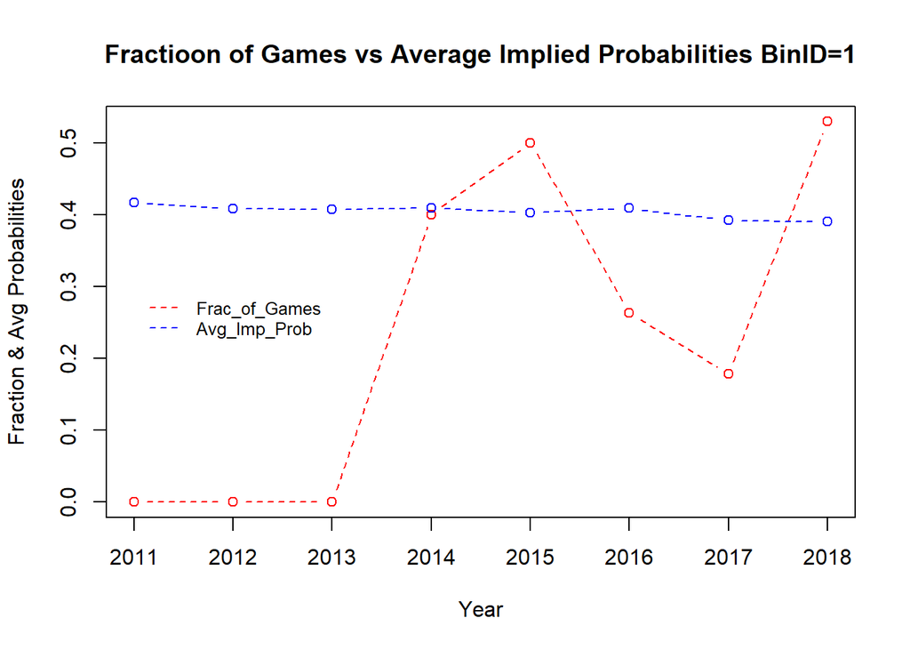

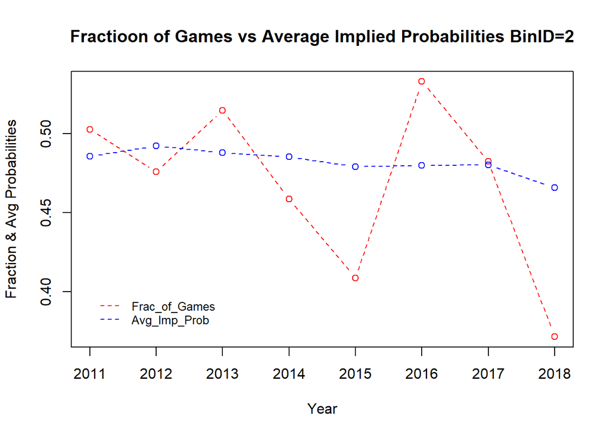

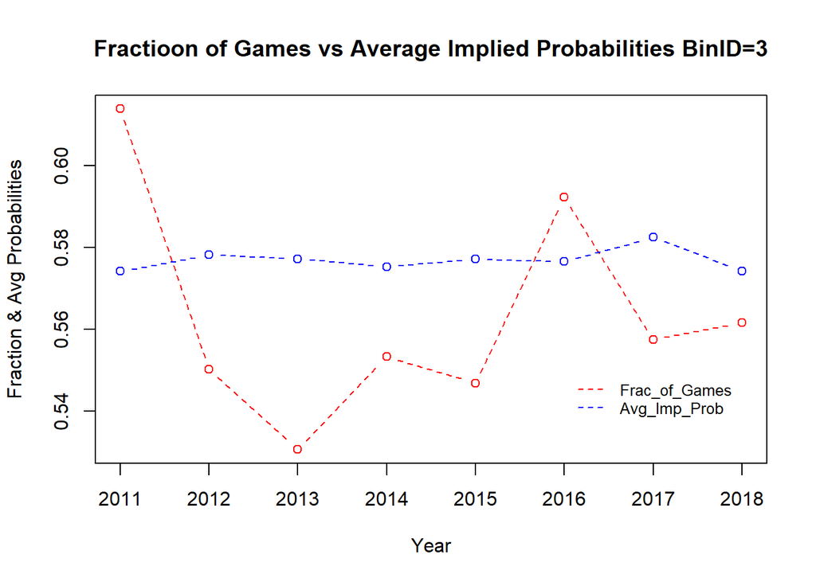

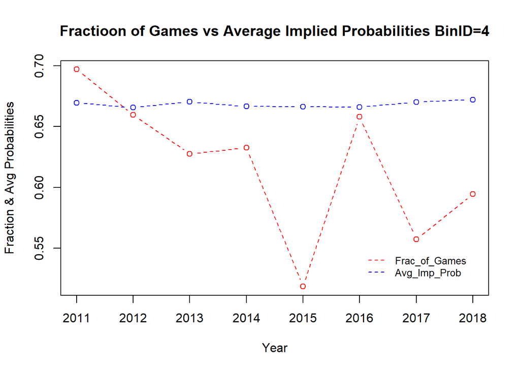

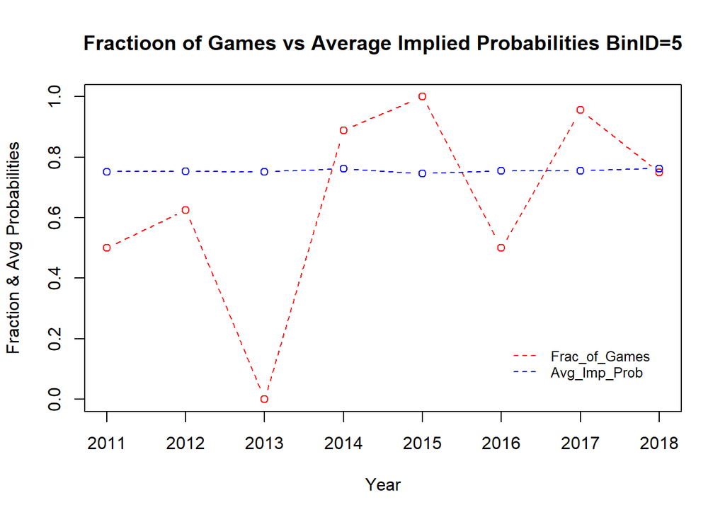

In all 5 graphs, average implied probabilities are almost constant while the fraction of games that finished over is fluctuating. Our concers it to detect if there is any imrovement in a way that the fraction of games and average probability get closer over years or not. As a conclusion from all these graph, no improvement is detected because these lines don’t behave like they are converging. There is not a pattern of getting closer. On the other hand, while the bookmaker is successful in some years, it may not be successfull in rest of the years as observed in graphs. Therefore, we can conclude that,the bookmaker is not consistently good at determining odds.

## Task 2

As a task 2, I choose to anaylze difference in scores and number of different odds on a single match. By this way, I would like to observe if the difference in scores is small, number of odds (including changing odds and different type of odds) is high. Small difference in scores intuitively means that powers of both teams are more or less equal and there is a high probability of draw. My hypothesis is that if there are so many changes in odds or many type of odds are provided for a game, the game will end with small difference in scores. In order to do that, I followed the steps that are shown below.

Chose a bookmaker which is Betclic for my case and filter the data by 1x2 bet type:

```r
all_data_DT<-data.table(all_data)
betclic<-all_data_DT[betType=="1x2" & bookmaker=="Betclic"]
```

Define a new column for difference in scores:

```r
betclic$score1 = as.numeric(lapply(strsplit(as.character(betclic$score), split=":"), "[", 1))
betclic$score2 = as.numeric(lapply(strsplit(as.character(betclic$score), split=":"), "[", 2))
betclic[,Score_diff:=abs(score1-score2)]
```

Compute the frequencies of MatchId’s and merge with my data:

```r
number_of_odds<-data.table(table(betclic$matchId))
names(number_of_odds)[1] <- "matchId"
data<-data.table(merge(number_of_odds,betclic,by="matchId"))
```

Eliminate dublicated MatchId’s:

```r
data<-unique(data,by="matchId")
```

Plot the difference in scores vs frequencies:

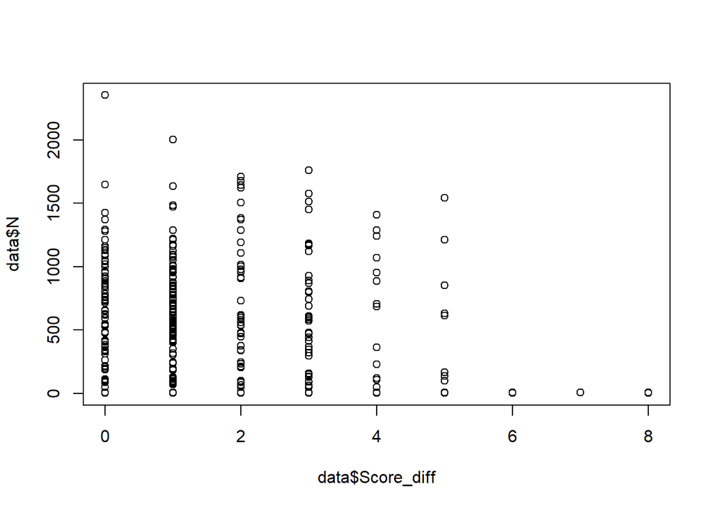

```r
plot(data$Score_diff,data$N)
```

From this graph, high number of frequencies are generally for the games that have small score difference. If frequency of odds is low for a game, the game will probably end with a high score difference. On the contrary, if the frequeny of odds is high for a game, the game will probably end with a small score difference. Additionally, apart from the frequency, the number of games that the bookmaker provides odd is high for the games that ended with small score difference. It can be seen in the graph that, there are more points for the small score differences. This shows us that bets are generally provided for the games which result are more unpredictible.